# Stats 453 Project

Debbie, Jacky, Zixuan

2/8/2021

```r
library(dplyr)

library(survival)
library(survminer)
library(stargazer)
Employ = read.csv('turnover.csv')
```

## Survival Analysis on Employee Turnover

### Introduction & Motivation

Employment turnover, which is the measurement of the number of employees who leave an organization during a specified time period, is essential to both the companies as well as employees. The length of service varies in different profession, organization. For example, the higher turnover rate of a company compared to others in the same industry might suggest that employees are suffering from excessive workload. However, the high turnover rate in the finance industry indicates the fast pace of natural career progression in that industry. That is why in past years, many researchers were intrigued by the key determination of turnover rate. In the year of 2000, three scientists examine the interrelationships between employee turnovers by combining all existing literature on employee turnover. Their research resulted in a meta-analysis of over 60, 000 employees. Therefore, it is important to know what causes the employees to leave the company; and we would study this by examining key factors that might affect the length of service using survival analysis. Therefore, it is important to know what causes the employees to leave the company; and we would study this by examining key factors that might affect the length of service using survival analysis.

### Data Description

We found this dataset form Kaggle, which is a real dataset shared from Edward Babushkin’s blog to predict an Employee’s risk of quitting. This dataset contains information of employee turnover data, which includes each individual’s information. Below is the detailed description of variables in this dataset:

`stag`: number of months that each individual stayed in one company. `event`: 0=censored, 1= exact observation. `gender`: m=male, f=female `age`: age in years `industry`: industry of the company that each individual worked for `profession`: profession of each individual `traffic`: From what pipelene employee came to the company `coach`: Presence of a coach on probation `head_gender`: the gender of the head. m=male, f=female `way`: Employee’s way of transportation `greywage`: The salary does not seem to the tax authorities `independ`: Independent score `selfcontrol`: Selfcontrol score `anxiety`: Anxiety score `extraversion`: Extroversion score `novator`: Novator score

We would use `stag` as the dependent variable because it reflects the length of service (survival time) of an individual.

### Survival Models

In our analysis, we would employ three approaches: parametric, non-parametric, and CoxPH models and see if they reach the same conclusions. In our parametric models, we would build three classical parametric model in survival analysis and then conduct AIC and LRT to choose the ideal parametric setting; and then, we would continue using AIC and LRT tests for variable selection. In our non-parametric analysis, we would examine the effect of the key variables informed by our parametric model on the survival time and check if the conclusions are consistent.

#### Parametric Estimation

Akaike’s Information Criterion (AIC): AIC is an estimator of prediction error and thereby relative quality of statistical models for a given set of data. AIC estimates the relative amount of information lost by a given model: the less information a model loses, the higher the quality of that model. AIC penalizes larger models, thus, the model with a lower AIC score is better than a bigger AIC score.

Weibull model has the lowest AIC score among these three models. Thus, we conclude that Weibull model is the best model in our parametric estimation.

```r
# Weibull AFT model
Employ = Employ%>%
  mutate(profession = replace(profession,profession == "Finan\xf1e","Finance"))
m1 = survreg( Surv(stag,event) ~ gender+age+ factor(profession)+ head_gender + way + independ + selfcontrol, dist='weibull', data=Employ )
```

```r
# Log-normal model
m2 = survreg( Surv(stag,event) ~ gender+age+ factor(profession)+ head_gender + way + independ + selfcontrol, dist='lognormal', data=Employ )
```

```r
# Exponential model
m3 = survreg( Surv(stag,event) ~ gender+age+ factor(profession)+ head_gender + way + independ + selfcontrol, dist='exponential', data=Employ )
```

```r
stargazer(m1, m2, m3, title=" Results",align=TRUE, dep.var.labels=c("Service"),type = 'html',
covariate.labels=c("gender","age","BusinessDevelopment","Commercial","Consult","Engineer", "Other professions","Finance","HR","IT","Law","manage","Marketing","PR","Sales", "Teaching","gender of head","car","foot","independ","selfcontrol "))
```

**Results**

|  | *Dependent variable:* |  |  |
| --- | --- | --- | --- |
|  | Service |  |  |
|  | *Weibull* | *survreg: lognormal* | *exponential* |
|  | (1) | (2) | (3) |
| gender | 0.150 | 0.171 | 0.167 |
|  | (0.109) | (0.120) | (0.120) |
| age | -0.020*** | -0.024*** | -0.019*** |
|  | (0.006) | (0.006) | (0.006) |
| BusinessDevelopment | -0.551 | -1.035** | -0.572 |
|  | (0.439) | (0.514) | (0.487) |
| Commercial | -1.015** | -1.424*** | -1.059** |
|  | (0.440) | (0.525) | (0.489) |
| Consult | -0.931** | -1.064** | -0.944* |
|  | (0.441) | (0.523) | (0.489) |
| Engineer | -1.066** | -1.298** | -1.107** |
|  | (0.471) | (0.563) | (0.522) |
| Other professions | -0.786* | -1.091** | -0.788* |
|  | (0.423) | (0.496) | (0.470) |
| Finance | -0.471 | -0.599 | -0.505 |
|  | (0.453) | (0.549) | (0.503) |
| HR | -0.531 | -0.813* | -0.524 |
|  | (0.376) | (0.444) | (0.417) |
| IT | -0.232 | -0.506 | -0.196 |
|  | (0.420) | (0.485) | (0.467) |
| Law | -0.690 | -0.674 | -0.704 |
|  | (0.550) | (0.669) | (0.610) |
| manage | -1.226*** | -1.357*** | -1.247** |
|  | (0.438) | (0.524) | (0.487) |
| Marketing | -0.934** | -1.487*** | -0.984** |
|  | (0.421) | (0.502) | (0.467) |
| PR | -0.982* | -0.945 | -1.028* |
|  | (0.552) | (0.712) | (0.613) |
| Sales | -0.668* | -1.136** | -0.695 |
|  | (0.405) | (0.477) | (0.450) |
| Teaching | -0.811* | -1.458** | -0.894* |
|  | (0.458) | (0.572) | (0.508) |
| gender of head | -0.028 | -0.007 | -0.041 |
|  | (0.084) | (0.095) | (0.093) |
| car | 0.204** | 0.235** | 0.206** |
|  | (0.088) | (0.099) | (0.098) |
| foot | 0.456*** | 0.469*** | 0.489*** |
|  | (0.149) | (0.159) | (0.165) |
| independ | 0.008 | -0.015 | 0.005 |
|  | (0.023) | (0.027) | (0.025) |
| selfcontrol | 0.053*** | 0.053** | 0.055** |
|  | (0.020) | (0.023) | (0.022) |
| Constant | 4.965*** | 5.084*** | 4.985*** |
|  | (0.445) | (0.513) | (0.493) |
| Observations | 1,129 | 1,129 | 1,129 |
| Log Likelihood | -2,982.099 | -2,982.459 | -2,986.960 |
| chi<sup>2</sup> (df = 21) | 64.351*** | 64.316*** | 58.694*** |
| *Note:* | p<0.1; p<0.05; p<0.01 |  |  |

```r
AIC <- tibble(
  Model = c("Exponential", "Weibull", "Lognormal"),
  AIC = c(6018,6010.2,6011)
  )
AIC
```

```
## # A tibble: 3 x 2
##   Model         AIC
##   <chr>       <dbl>
## 1 Exponential 6018
## 2 Weibull     6010.
## 3 Lognormal   6011
```

Since the AIC score of the Weibull model is the smallest, we would continue our analysis using Weibull distribution.

##### Variable Selection.

We find out that Weibull model is the best model for parametric estimation. Next, we want to investigate the appropriate set of variables for our Weibull model.

We will continue to use the AIC to find the appropriate set of parameters. Furthermore, we incorporate the Likelihoods Ratio Tests (LRT) to ensure the results of AIC. The likelihood-ratio test assesses the goodness of fit of two competing statistical models based on the ratio of their likelihoods, specifically one found by maximization over the entire parameter space and another found after imposing some constraint. If the constraint (i.e., the null hypothesis) is supported by the observed data, the two likelihoods should not differ by more than sampling error. Thus the likelihood-ratio test tests whether this ratio is significantly different from one, or equivalently whether its natural logarithm is significantly different from zero.

First, we have the original set of parameters. Next, we are going to assess if we should include `head-gender`, `independ`, and `gender`, which have the largest P-value (insignificance) in our Weibull model. Then, we would use the AIC test to determine whether we should include these variables.

```r
m4 = survreg( Surv(stag,event) ~ age+ factor(profession) + way + selfcontrol, dist='weibull', data=Employ )
```

The AIC score of simpler model is 6006.2, which is lower than the original Weibull model that has all parameters. However, we still find out that some of the parameters in `profession` has high P-value, and ‘profession’ generates 14 parameters because it is categorical. Therefore, we also want to see we should incorporate ‘profession’ in our model.

```r
m5 = survreg( Surv(stag,event) ~ age + way + selfcontrol, dist='weibull', data=Employ )
```

```r
stargazer(m4, m5, title=" Results",align=TRUE, dep.var.labels=c("Service"),type = 'html',
covariate.labels=c("age","BusinessDevelopment","Commercial","Consult","Engineer", "Other professions","Finance","HR","IT","Law","manage","Marketing","PR","Sales", "Teaching","car","foot","selfcontrol"))
```

**Results**

|  | *Dependent variable:* |  |
| --- | --- | --- |
|  | Service |  |
|  | (1) | (2) |
| age | -0.020*** | -0.021*** |
|  | (0.006) | (0.005) |
| BusinessDevelopment | -0.579 |  |
|  | (0.435) |  |
| Commercial | -0.998** |  |
|  | (0.436) |  |
| Consult | -0.899** |  |
|  | (0.437) |  |
| Engineer | -1.004** |  |
|  | (0.461) |  |
| Other professions | -0.790* |  |
|  | (0.421) |  |
| Finance | -0.460 |  |
|  | (0.452) |  |
| HR | -0.578 |  |
|  | (0.373) |  |
| IT | -0.192 |  |
|  | (0.412) |  |
| Law | -0.631 |  |
|  | (0.546) |  |
| manage | -1.244*** |  |
|  | (0.437) |  |
| Marketing | -0.955** |  |
|  | (0.419) |  |
| PR | -1.002* |  |
|  | (0.552) |  |
| Sales | -0.663* |  |
|  | (0.400) |  |
| Teaching | -0.859* |  |
|  | (0.456) |  |
| car | 0.221** | 0.236*** |
|  | (0.087) | (0.084) |
| foot | 0.445*** | 0.407*** |
|  | (0.149) | (0.147) |
| selfcontrol | 0.054*** | 0.057*** |
|  | (0.019) | (0.019) |
| Constant | 5.047*** | 4.470*** |
|  | (0.424) | (0.203) |
| Observations | 1,129 | 1,129 |
| Log Likelihood | -2,983.149 | -2,996.805 |
| chi<sup>2</sup> | 62.251*** (df = 18) | 34.938*** (df = 4) |
| *Note:* | p<0.1; p<0.05; p<0.01 |  |

```r
AIC_w=tibble(
  Model = c("All predictors", "age, profession,way,self control", "age, way, self control"),
  AIC = c(6010.2,6006.2,6005.6)
  )
AIC_w
```

```
## # A tibble: 3 x 2
##   Model                              AIC
##   <chr>                            <dbl>
## 1 All predictors                   6010.
## 2 age, profession,way,self control 6006.
## 3 age, way, self control           6006.
```

```r
LRT=tibble(
  Model = c("All predictors vs. age, profession,way,self control", "age, way, self control vs. age, profession,way,self control", "All predictors vs. age, way, self control"),
  Test_statistics = c(2.1,27.312,29.412),
  P_value=c(0.5519128, 0.01753144,0.03091084)
  )
LRT
```

```
## # A tibble: 3 x 3
##   Model                                                  Test_statistics P_value
##   <chr>                                                            <dbl>   <dbl>
## 1 All predictors vs. age, profession,way,self control                2.1  0.552
## 2 age, way, self control vs. age, profession,way,self c…            27.3  0.0175
## 3 All predictors vs. age, way, self control                         29.4  0.0309
```

#### Non-Parametric Estimation

Informed by our parametric models, we would explore the effect of age, way, and self-control on the survival time from the non-parametric perspective.

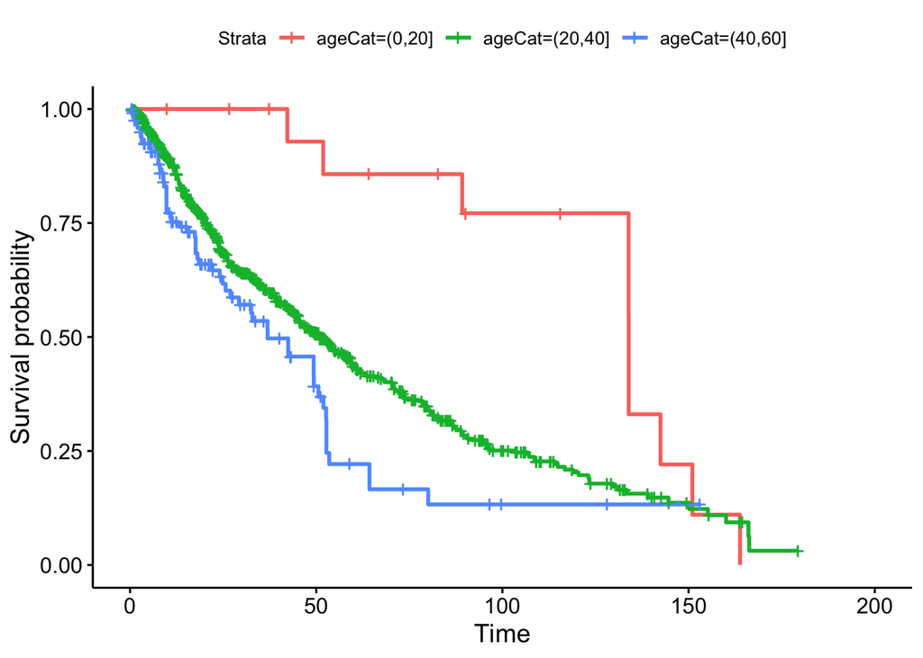

```r
Employ$ageCat = cut(Employ$age, c(0, 20,  40,  60))
Employ$scCat = cut(Employ$selfcontrol, c(0, 4,  8 , 10))
m6 = survfit( Surv(stag,event) ~ageCat, data=Employ  )
ggsurvplot(m6)
```

According to the graph above, it is clear that the length of service can be affected by the age of the employees. On average, we would expect the employment turnover rate of the younger people to be the lowest; and it is possible that the turnover rate increases as one gets older. However, since we cut the continuous variable into three categories, we don’t know if it is true that the increase in age would necessarily lead to the increase in employment turnover rate.

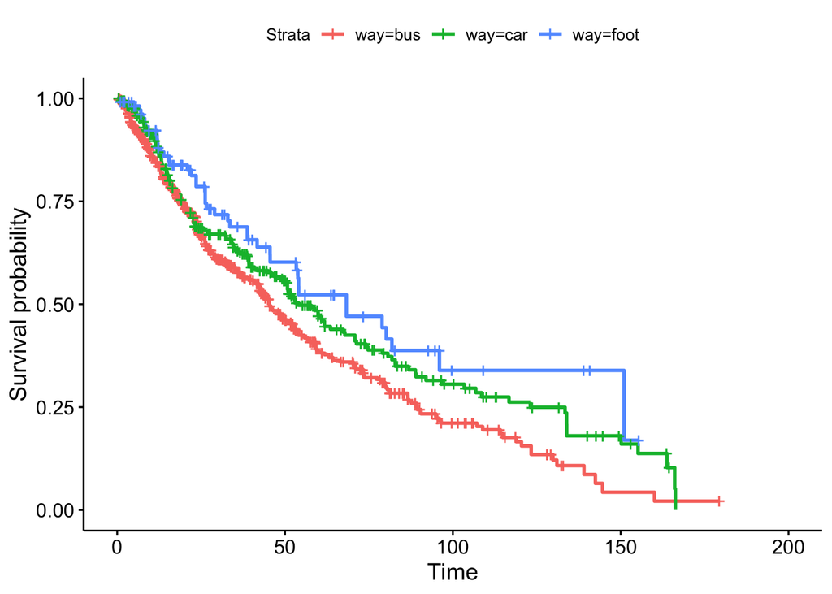

```r
m7 = survfit( Surv(stag,event) ~ way , data=Employ  )
ggsurvplot(m7)
```

According to the graph above, we can see that at the first ten months approximately, the length of service of employees using different transportions is similar. However, as they work longer, people who go to work by bus seem to be more likely to leave their companies; and people who walk to work are the least likely to leave. It is possible that people who walk to their workplace also live closer to their companies; and the shorter distance would make them less likely to leave or relocate. For people who take bus or drive to work, we might expect their distance to companies is further; thus, their willingess to leave the company might be higher.

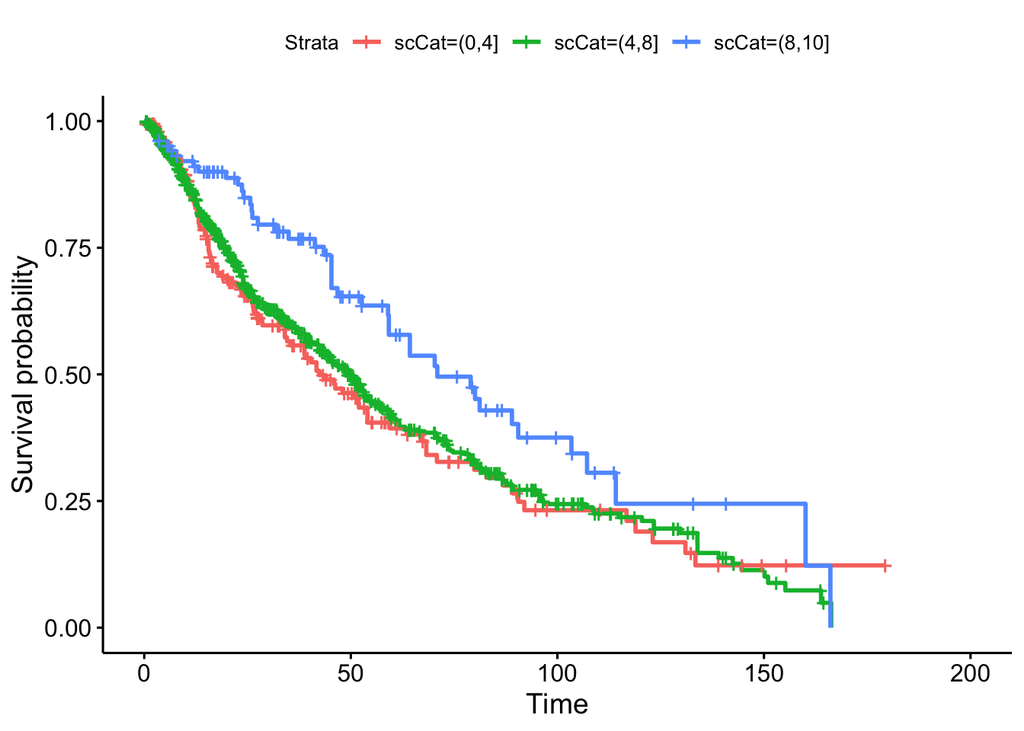

```r
m8 = survfit( Surv(stag,event) ~ scCat, data=Employ  )
ggsurvplot(m8)
```

Based on the graph, we can see that people who self-reported to be more self-control are more likely to stay in their companies longer. It is also interesting that the length of service of the groups of 0-4 and 4-8 are very similar, it might suggest that employees who are extremely disciplined would be more likely to continue working in the same company. However, we cut the quantitative variable into 3 categories, and we didn’t show the survival probabilities of other employees with greater details. Therefore, we only know that the length of service of more self-controlled employees are longer but we can’t be certain on how it affects the turnover rate specifically.

#### Semi-parametric Approach: CoxPH

The purpose of the model is to evaluate simultaneously the effect of several factors on survival. In other words, it allows us to examine how specified factors influence the rate of a particular event happening (e.g., infection, death) at a particular point in time. This rate is commonly referred as the hazard rate.

The Cox model is expressed by the hazard function denoted by h(t), and the model assumes that the risk of failure of two groups is always proportional. Briefly, the hazard function can be interpreted as the risk of dying at time t. It can be estimated as follow:

$$h(t)=h_0(t)×e^{b_1x_1+b_2x_2+...+b_px_p}$$

where, t represents the survival time

h(t) is the hazard function determined by a set of p covariates (x1,x2,…,xp)

the coefficients (b1,b2,…,bp) measure the impact (i.e., the effect size) of covariates.

the term $h_0$ is called the baseline hazard. It corresponds to the value of the hazard if all the xi are equal to zero (the quantity exp(0) equals 1). The ‘t’ in h(t) reminds us that the hazard may vary over time.

The Cox model can be written as a multiple linear regression of the logarithm of the hazard on the variables xi, with the baseline hazard being an ‘intercept’ term that varies with time.

The quantities exp(bi)are called hazard ratios (HR). A value of bi greater than zero, or equivalently a hazard ratio greater than one, indicates that as the value of the ith covariate increases, the event hazard increases and thus the length of survival decreases.

Put another way, a hazard ratio above 1 indicates a covariate that is positively associated with the event probability, and thus negatively associated with the length of survival.

In summary,

HR = 1: No effect

HR < 1: Reduction in the hazard

HR > 1: Increase in Hazard

```r
m9 = coxph( Surv(stag,event) ~  age + way + selfcontrol, data=Employ  )
stargazer(m9,type = 'html')
```

|  | *Dependent variable:* |
| --- | --- |
|  | stag |
| age | 0.023*** |
|  | (0.006) |
| waycar | -0.265*** |
|  | (0.094) |
| wayfoot | -0.455*** |
|  | (0.162) |
| selfcontrol | -0.060*** |
|  | (0.021) |
| Observations | 1,129 |
| R<sup>2</sup> | 0.029 |
| Max. Possible R<sup>2</sup> | 0.998 |
| Log Likelihood | -3,453.470 |
| Wald Test | 33.660*** (df = 4) |
| LR Test | 33.663*** (df = 4) |
| Score (Logrank) Test | 33.844*** (df = 4) |
| *Note:* | p<0.1; p<0.05; p<0.01 |

```r
cox.zph(m9)
```

```
##             chisq df    p
## age         0.415  1 0.52
## way         0.595  2 0.74
## selfcontrol 1.361  1 0.24
## GLOBAL      2.249  4 0.69
```

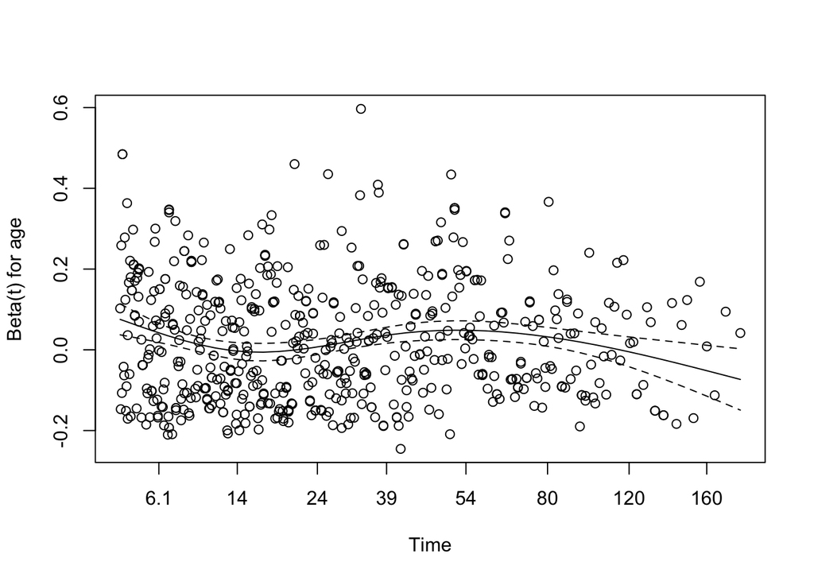

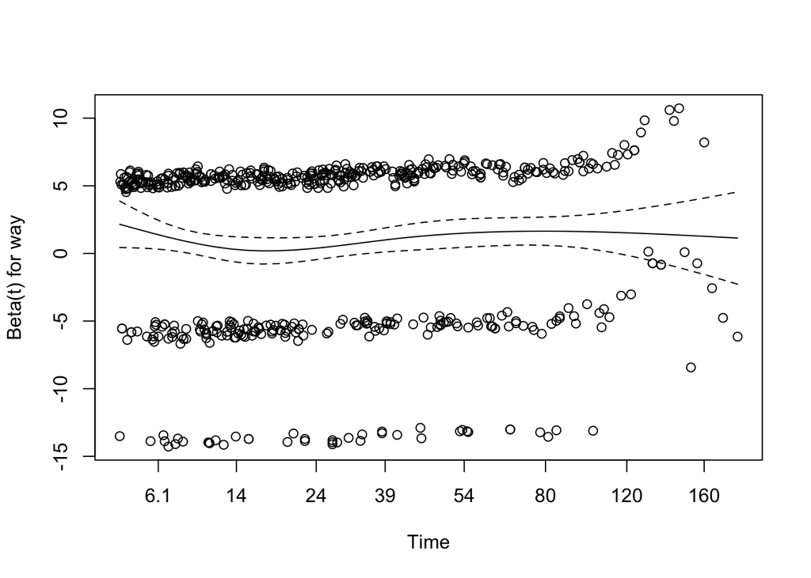

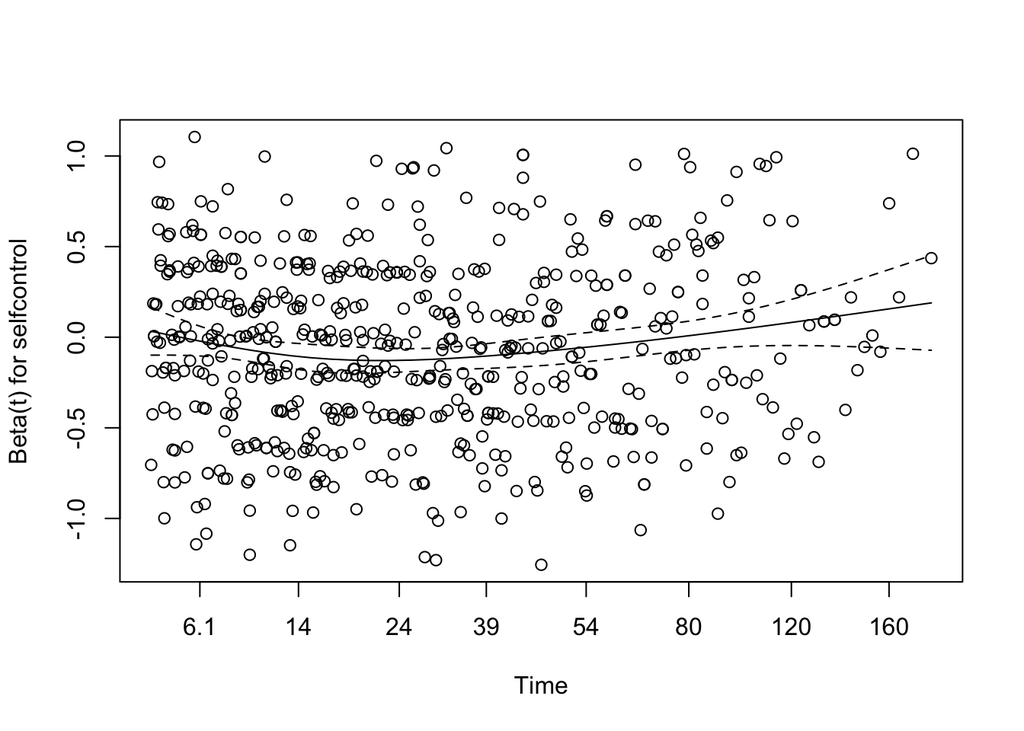

```r
plot(cox.zph(m9))
```

According to the test on the PH assumption, neither of them is significant because their p-value are very large. This is also consistent with the residual plot as the fitted curves are relatively flat over time. However, the curve for age seems to go down at the end, and we might have a different conclusion if we could have more observations. Therefore, neither of them seems to have a time-varying effect, but it could also due to the limited number of observations.

### Conclusion

In our parametric and non-parametric approach, we find out that, on average, younger individuals tend to have longer survival times. In other words, as we set three age ranges, the younger age range stay longer in one company. Moreover, the more convenient one commutes, the longer one will stay in one company. (One goes to work by foot has the longest survival times, and one goes to work by bus has the shortest survival time). For self control score, the one with higher self-control score tends to have longer survival times. In our semi-parametric model, we find out that these three predictors do not have time-varying impact (The PH assumption holds).

### Limitation

There are several limitations in our analysis. First, the data was collected in Russia; therefore, it might be problematic if we try to extrapolate to other countries. Second, there are many parametric settings, and we only choose three of those; it is possible that other parametric models might lead us to different conclusions. Third, we select key variables after choosing the parametric settings; however, it is also possible that we omit a variable due to the order of our analysis. For example, another variable might be significant in exponential model but it is insignificant in weibull model.